# 第9回 顔画像を、少ない数で持つ

# 6. 見分ける力は残るか？

## まず見分ける方法を決める

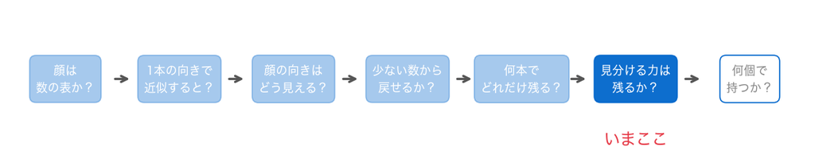

- 50個の数で持った顔で、誰の顔かを見分けられるか
- まず、見分ける方法を決める

## 名前：1-最近傍法

6節 ① 1-最近傍法●○

- カメラに写った顔に、いちばん近い登録の顔を探す
- その人だと答える方法を、1-最近傍法と呼ぶ
- 訓練の300枚を登録の顔、テストの顔をカメラの顔とみなす

## 近さは差の二乗の和

6節 ① 1-最近傍法●●

$$d(\mathbf{x}, \mathbf{x}_j) = \sum_{\text{画素}} (\text{差})^2 = \|\mathbf{x} - \mathbf{x}_j\|^2$$

- 2つの顔の、画素ごとの差の二乗を足す
- 小さいほど近い

## お手本：いちばん近い顔

6節 ② 1枚で探す●○○

```python
x = X_te[0]
d = ((X_tr - x) ** 2).sum(axis=1)  # 300枚それぞれとの距離
near = np.argmin(d)
print(round(d[near], 2), p_tr[near], p_te[0])
show_faces([x, X_tr[near]], ['テストの顔', 'いちばん近い顔'])
```

- `sum(axis=1)`：横の方向（行ごと）に足す

## 表から1行を引く

6節 ② 1枚で探す●●○

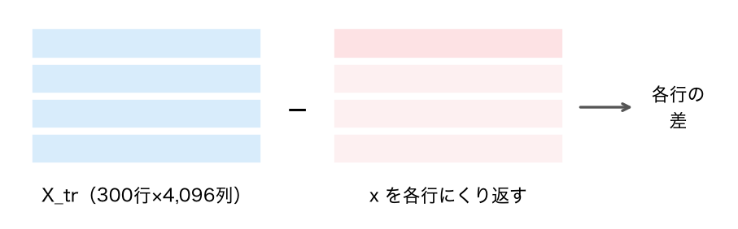

- `X_tr - x`：`x`を300行ぶんくり返して、各行から引く
- ブロードキャストと呼ぶ。1節で平均の顔を引いたのも、この形

## 同じ人が見つかった

6節 ② 1枚で探す●●●

```
16.7 36 36
```

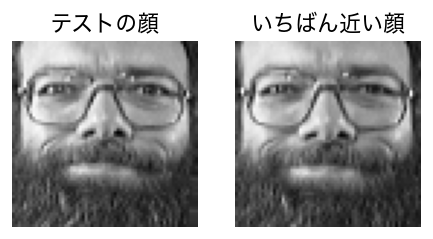

- いちばん近い顔は、番号が同じ36の人。当たり

## 部品：KNeighborsClassifier

6節 ③ 部品●○

- いちばん近い顔を探して答える部品
- `n_neighbors=1`：いちばん近い1枚の答えを使う

## fit・predict・score

6節 ③ 部品●●

- `fit`：登録の顔と人の番号を、そのまま覚える
- `predict`：新しい顔ごとに、いちばん近い1枚の番号を返す
- `score`：当てた割合（正解率）を返す（第6回）

## 比べるのは交差検証で

6節 ④ 画素そのまま●○○

- テストは最後に1回だけ。本数の比べ合いは、訓練の300枚の交差検証で（第4回）
- 人ごとの割合をそろえて5つに分ける（`StratifiedKFold`、第6回）

## お手本：画素そのまま

6節 ④ 画素そのまま●●○

```python
skf = StratifiedKFold(n_splits=5, shuffle=True, random_state=0)
knn = KNeighborsClassifier(n_neighbors=1)
sc_raw = cross_val_score(knn, X_tr, p_tr, cv=skf)
print(sc_raw.round(3))
print(round(sc_raw.mean(), 3))
```

- 分類の部品では、`cross_val_score`は正解率を返す

## 4,096画素で0.907

6節 ④ 画素そのまま●●●

```
[0.9   0.883 0.917 0.9   0.933]
0.907
```

- 40人から、9割ほどを当てている
- これを、縮めたときに比べる相手にする

## お手本：50本に縮めてから

6節 ⑤ 50本で見分ける●○○

```python
pipe50 = make_pipeline(PCA(n_components=50, random_state=0),
                       KNeighborsClassifier(n_neighbors=1))
sc_50 = cross_val_score(pipe50, X_tr, p_tr, cv=skf)
print(sc_50.round(3))
print(round(sc_50.mean(), 3))
```

- 主成分分析と1-最近傍法を、1本のパイプラインにつなぐ

## なぜパイプラインに？

6節 ⑤ 50本で見分ける●●○

- 交差検証の各回で、`PCA`は、その回の訓練の顔だけで向きを求める
- `PCA`は答えを使わないが、評価用の顔を見ずに向きを決められる
- 第7回・第8回の「手順は中へ」と同じ形

## 50本でも0.9

6節 ⑤ 50本で見分ける●●●

```
[0.9   0.883 0.9   0.917 0.9  ]
0.9
```

- 4,096画素そのままの0.907と、ほとんど変わらない

## 0.88しか残らないのに？

6節 ⑥ なぜ残るか●○

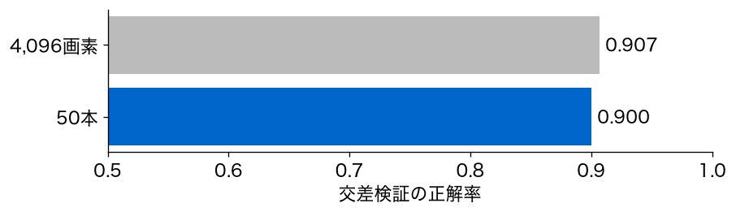

- 50本の累積寄与率は0.88。散らばりの1割強は捨てている

## 捨てたのは雑音のような違い

6節 ⑥ なぜ残るか●●

- 捨てた向きの多くは、人の違いではなく、細かい雑音のような違い
- 人を見分ける違いは、はじめの数十本の向きに入っている

## TODO⑤：20本では？

6節 ⑦ 20本では●○○○

```python
# TODO: 20本に縮めてから見分けるパイプラインで、交差検証の正解率を出す
# ヒント: pipe20 = make_pipeline(PCA(n_components=20, random_state=0),
#                                KNeighborsClassifier(n_neighbors=1))
#         cross_val_score(pipe20, X_tr, p_tr, cv=skf).mean()
...
```

## やってみよう：6節とTODO⑤

6節 ⑦ 20本では●●○○

- 6節のお手本を実行する
- TODO⑤で、20本に縮めたときの正解率を出す

動画の人は、ここで一時停止。

## 答え合わせ：TODO⑤

6節 ⑦ 20本では●●●○

```python
pipe20 = make_pipeline(PCA(n_components=20, random_state=0),
                       KNeighborsClassifier(n_neighbors=1))
print(round(cross_val_score(pipe20, X_tr, p_tr, cv=skf).mean(), 3))
```

```
0.877
```

## 少なくしすぎると落ちる

6節 ⑦ 20本では●●●●

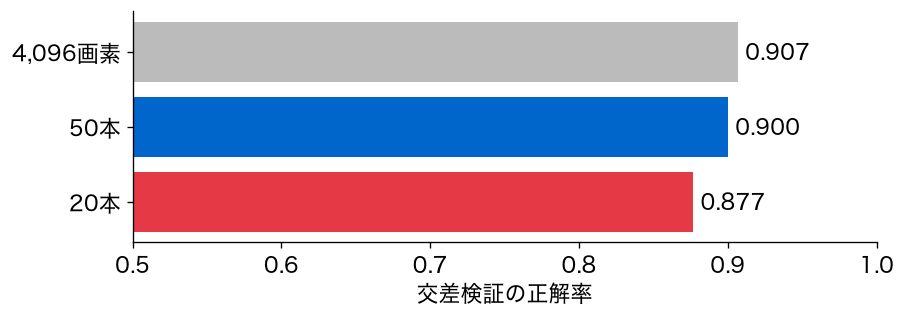

- 20本では0.877。50本の0.9より下がる

# 7. 何個の数で持てばよいか？

## 決めて、1回だけ確かめる

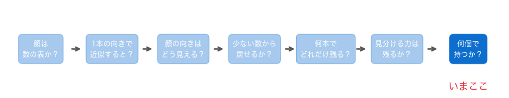

- 何個の数で持つかを決める
- まだ見ていないテストの100枚で、1回だけ確かめる

## 候補を並べる

7節 ① 50個を選ぶ●○○

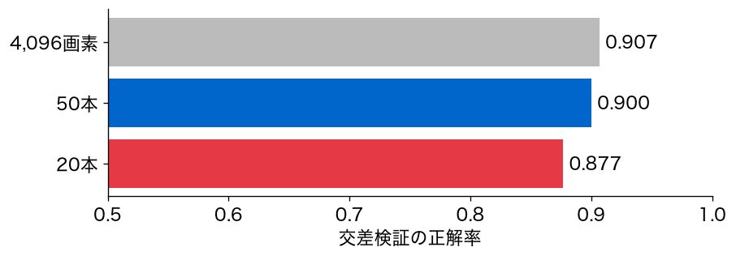

- 交差検証の正解率：4,096画素0.907、50本0.9、20本0.877

## お手本：何%の数か

7節 ① 50個を選ぶ●●○

```python
print(round(50 / 4096 * 100, 1), '%')
```

```
1.2 %
```

- 50本は、4,096画素とほぼ同じ力で、元の1.2%の数

## 50個を選ぶ

7節 ① 50個を選ぶ●●●

- ここでは、50個を選ぶ
- 選ぶのは、テストではなく交差検証の結果（第8回）

## お手本：テストで1回だけ

7節 ② テスト●○

```python
knn.fit(X_tr, p_tr)
pipe50.fit(X_tr, p_tr)
print(knn.score(X_te, p_te))
print(pipe50.score(X_te, p_te))
```

- 訓練の300枚全員で作り、テストの100枚の正解率を出す

## テストでもどちらも0.93

7節 ② テスト●●

```
0.93
0.93
```

- 50本にしても、テストで当たった枚数は変わらない

## お手本：外れた顔を見る

7節 ③ 外れた顔●○○

```python
pred = pipe50.predict(X_te)
miss = X_te[pred != p_te]
print(len(miss), '枚')
show_faces(miss[:4], ['外れ1', '外れ2', '外れ3', '外れ4'])
```

- `pred != p_te`：当てた番号と本当の番号が違う顔

## 外れたのは7枚

7節 ③ 外れた顔●●○

```
7 枚
```

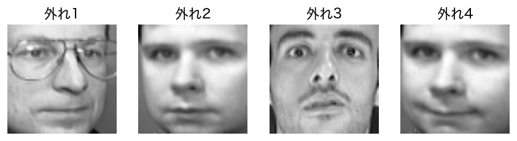

- どれも、人の目には普通の正面の写真

## 差の二乗和は人の目と違う

7節 ③ 外れた顔●●●

- 画素の差の二乗和で測ると、表情や明るさの似た別の人の写真のほうが近くなることがある
- 近さの測り方は、人の目の見分け方と同じではない

## 答え

7節 ④ 答え●○○

顔の画像1枚（4,096画素）は、主成分分析で50個の数（元の1.2%）にしても、誰の顔かを見分ける力はほとんど落ちない。

## 答えの数

7節 ④ 答え●●○

- 交差検証の正解率：4,096画素そのまま0.907、50本0.9
- テストの100枚：どちらも0.93
- 20本まで減らすと0.877に下がる。50個を目安に提案できる

## 1割強を捨てても

7節 ④ 答え●●●

- 50本の累積寄与率は0.88
- 捨てた1割強は、見分けるのにあまり役立たない違いだった

## まだ言えないこと①：撮り方

7節 ⑤ まだ言えないこと●○○

- このデータは、同じ部屋で、顔の位置をそろえて撮った写真
- 明るさや顔の位置が違うカメラでは、主成分の向きそのものが変わりうる

## まだ言えないこと②：人数

7節 ⑤ まだ言えないこと●●○

- 40人より多いときも同じかは分からない
- 登録する人が増えると、見分けるのに必要な本数も増えうる

## まだ言えないこと③：知らない人

7節 ⑤ まだ言えないこと●●●

- 1-最近傍法は、必ず誰かを答える
- 知らない人を「登録なし」と答える仕組みは、別に要る

# まとめ

## 今日の道筋を振り返る

⑥ 振り返る●○○○○○

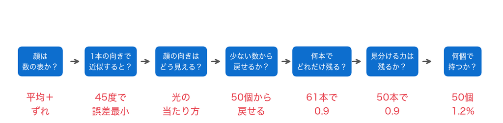

- 7つの小さな問いに答えて、50個で持てばよいと分かった

## 今日の歩み

⑥ 振り返る●●○○○○

行と画像 → 1本の向き → 固有顔 → 再構成 → 累積寄与率 → 1-最近傍法 → テスト

## 今日持ち帰る1文

⑥ 振り返る●●●○○○

主成分分析は、データを平均からのずれの「誤差が最小になる向き」で近似する。縮めるのも戻すのも行列の積で書け、顔なら4,096個の数を50個にしても、誰の顔かを見分ける力はほとんど落ちない。

## 今日の要点①：向き

⑥ 振り返る●●●●○○

- どの顔も、平均の顔＋ずれ
- 第1主成分は、誤差が最小の向き＝得点の散らばりが最大の向き
- 主成分分析は答えの列を使わない（教師なし学習）。向きを描いたものが固有顔

## 今日の要点②：縮める・戻す

⑥ 振り返る●●●●●○

- 得点＝ずれ`@`向きの転置、再構成＝得点`@`向き＋平均
- 累積寄与率は訓練の散らばりが何割残るか、再構成誤差はまだ見ていない顔をどれだけ戻せるか
- 見分ける力は、交差検証の正解率で別に確かめる

## 今日の要点③：Python

⑥ 振り返る●●●●●●

- `reshape(64, 64)`で、行を画像に戻す
- `mean(axis=0)`は縦の方向、`sum(axis=1)`は横の方向
- 表から1行を引くと、各行から引かれる（ブロードキャスト）

## 課題の出し方

⑦ このあと●○○○

- ノートの最後の「課題（提出）」に取り組む
- 応用②の答えと応用③の文章を、LACSに入力して提出（＝出席。期限なし）
- AIを使ってもよい。何を聞いて、どう直したかを1行書く

## 次回予告：向きを読む

⑦ このあと●●○○

- 今日は、向きを顔として描き、明るさや光の当たり方と読んだ
- 画像なら、向きを絵にして読める

## 次回の問い

⑦ このあと●●●○

身長や価格のように、単位も意味も違う列が並んだデータでは、主成分の向きや得点を、どう読めばよいか？

## このあと：課題へ

⑦ このあと●●●●

ノートの「課題（提出）」へ。主成分の本数を変えて、見分ける力を比べ直します。

# ここから先は解答

## 課題のあとで見る

課題（提出）に取り組んでから見てください。動画の人は、ここで一時停止。

## 応用①：本数を変える

```python
for k in [10, 30, 100]:
    pipe = make_pipeline(PCA(n_components=k, random_state=0),
                         KNeighborsClassifier(n_neighbors=1))
    sc = cross_val_score(pipe, X_tr, p_tr, cv=skf)
    print(k, round(sc.mean(), 3))
```

```
10 0.803
30 0.893
100 0.907
```

## 本数と正解率

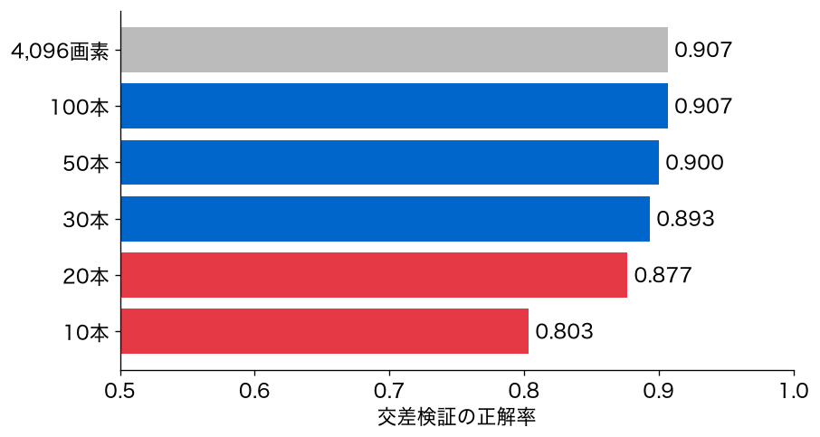

- 100本で4,096画素と同じ0.907。10本では0.803

## 応用②：答えは50本

```
0.013 0.007
```

- 4,096画素（0.907）との差：30本は0.013、50本は0.007
- 差が0.01より小さい、いちばん少ない本数は50本

## 応用③：模範例

顔の画像1枚（4,096画素）は、主成分分析で50個の数（元の1.2%）にしても、見分ける力はほとんど落ちませんでした（交差検証の正解率0.9、4,096画素そのままで0.907）。20本まで減らすと0.877に下がるので、50個を目安に持つことを提案します。ただし、同じ部屋で顔の位置をそろえて撮った40人の写真での結果なので、実際のゲートのカメラの写真や、登録していない人の扱いは、別に確かめる必要があります。

## 書き方の型

- 1文目：何個で持つと、見分ける力がどれだけ残るか（数で）
- 2文目：提案（減らしすぎるとどうなるか）
- 3文目：まだ確かめていないこと

# 発展（任意）

## 固有顔の向きに動かす

- 3節で、第1主成分は顔全体の明るさ、第2主成分は光の当たり方と読んだ
- 平均の顔を、その向きに沿って動かすと、本当にそう変わるか

## お手本：第1主成分の向きへ

```python
sd = np.sqrt(pca.explained_variance_[0])   # 第1主成分の得点の標準偏差
faces = []
for c in [-2, -1, 0, 1, 2]:
    faces.append(mean_face + c * sd * pca.components_[0])
show_faces(faces, ['−2', '−1', '0', '+1', '+2'])
```

- `explained_variance_`：各主成分の得点の分散。`np.sqrt`で標準偏差に

## 明るさが変わる

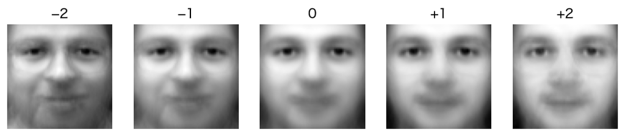

- ＋の側では顔が明るく、まわりが暗くなる。真ん中（0）が平均の顔

## 第2主成分の向きへ

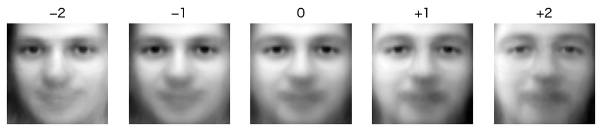

- `[0]`を`[1]`に変えると、＋の側では顔の左半分が明るく、右半分が暗くなる

## 試すなら

- `[2]`や`[3]`に変えて、どんな違いが見えるかを確かめる

## 第8回の平均と比べる

- 第8回：527本の遺伝子のまとまりを、標準化した発現量の平均で1本の点数にした
- 同じ527本に主成分分析をかけ、第1主成分の得点と比べる

## お手本：遺伝子のまとまり

```python
from scipy.cluster.hierarchy import linkage, fcluster
rat = pd.read_csv(f'{DATA_DIR}/rat_eye_full.csv.gz', index_col=0)
g_tr, g_te = train_test_split(rat.drop(columns='TRIM32'),
                              test_size=0.25, random_state=0)
g_tr = g_tr.loc[:, ~g_tr.columns.str.startswith('AFFX')]
g_tr = g_tr.loc[:, g_tr.mean() > g_tr.mean().median()]
var_top = g_tr.var().sort_values(ascending=False).index[:2000]
Z = linkage(g_tr[var_top].T, 'average', metric='correlation')
groups = pd.Series(fcluster(Z, 10, 'maxclust'), index=var_top)
Zs = (g_tr[var_top] - g_tr[var_top].mean()) / g_tr[var_top].std()
g7 = Zs.loc[:, groups == 7]
avg7 = g7.mean(axis=1)                       # 第8回の点数
pca7 = PCA(n_components=1).fit(g7)
s7 = pca7.transform(g7)[:, 0]                # 第1主成分の得点
print(g7.shape)
print(pca7.explained_variance_ratio_.round(3))
print(np.corrcoef(avg7, s7)[0, 1].round(3))
```

## 第8回のセルをまとめたもの

- 前半は、第8回の読み込み・列の選び方・階層的クラスタリング
- 最後の4行が、平均の点数と第1主成分の得点

## 相関0.994

```
(90, 527)
[0.394]
0.994
```

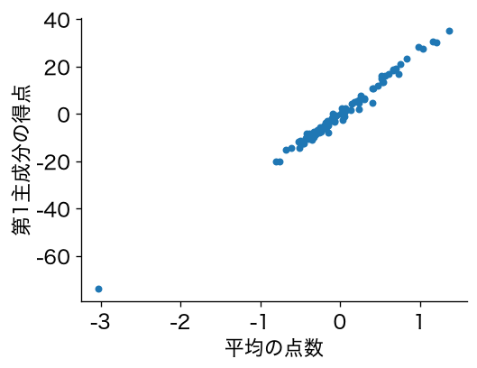

## 平均と主成分の違い

- 平均：527本すべてに、同じ重みを付けて足す
- 主成分分析：誤差が最小になるように、遺伝子ごとに重みを決める
- 一緒に動くまとまりでは、重みがほぼそろうので、2つはほぼ一致

## 平均は単純な近似

- 第8回の平均は、第1主成分のいちばん単純な近似だった
- 試すなら、`pca7.components_[0]`を`plt.hist`で描き、重みが$1/\sqrt{527}$のまわりに集まるかを見る

## おわり

- 今日は、顔の画像1枚を、4,096個から50個の数に縮めた
- 縮めても、誰の顔かを見分ける力はほとんど落ちなかった